# Analysis of honeybee drone activity during the mating season in Northwestern Argentina

Data Analysis

Philipp Gärtner

9/24/2020

This GitHub repository contains the data and figures accompanying the manuscript

**Analysis of honeybee drone activity during the mating season in Northwestern Argentina**

by Marta Ayup, Philipp Gärtner, José Agosto-Rivera, Peter Marendy, Paulo de Souza and Albertos Galindo-Cardona

The data presented here are licensed under the CC BY-SA 4.0 international license, a copy of which can be found [here](https://creativecommons.org/licenses/by-sa/4.0/). Under this license, you can copy and redistribute the material in any medium or format as long as you give appropriate credit, provide a link to the license, and indicate if changes were made.

Additional information concerning the data is available upon request from the authors. Please send a mail to agalindo@tucuman-conicet.gov.ar for more information.

## Software

All analysis and figures were performed with R 4.0.3.

## Data

The ‘data’ folder contains the all data files.

Back to Top

## Figures

### Drone arrival & departure times during the year

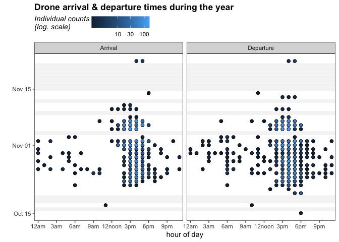

Arrival Time (left panel) and Departure (right panel) of the drones marked with RFID in Tucumán. The color gradient goes from black to blue, where black are few individual counts and blue to more than 100 counts. Grey bars indicate days without activity. The time of day is in UTC, which indicates 3 hours less in NO Argentina.

Back to Top

### Drone departure counts in the morning

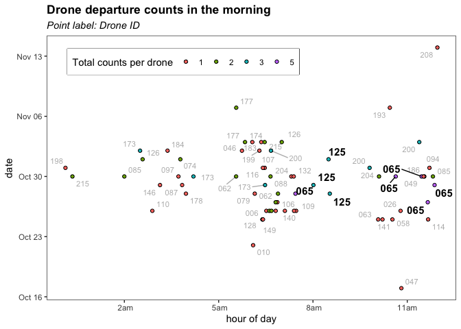

Back to Top

### Drone activity groups

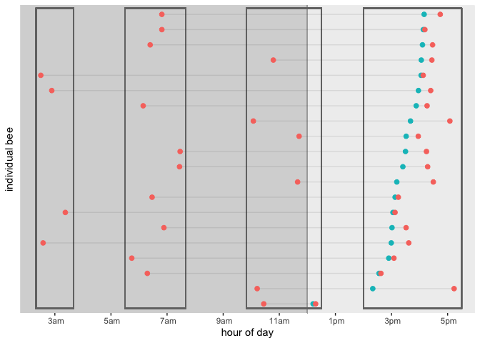

Drones that were active in hour groups during the day. Departure (red) and arrival (green).

Back to Top

### Dawn and morning activity of drones

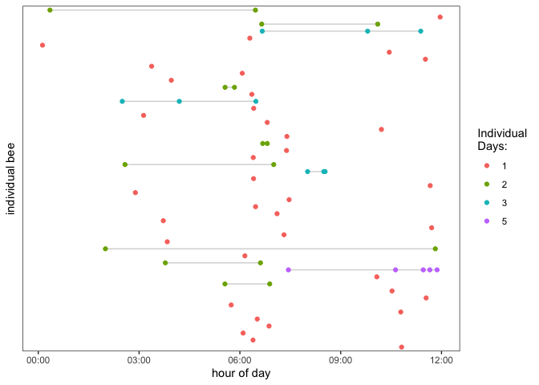

Dawn and morning activity of drones in different days during the experiment.

Back to Top

### Number of flights in the solar time

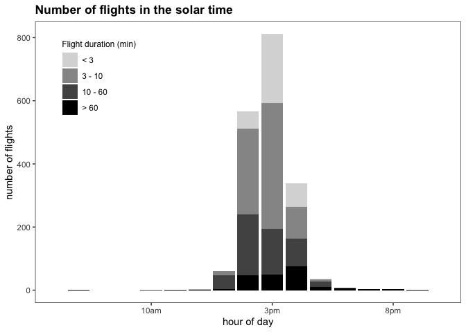

Flight duration time in minutes and departure in the solar time of drones marked with RFID during the nuptial flights season in NW Argentina.

Back to Top

### Number of days each drone remains inside and outside the hive

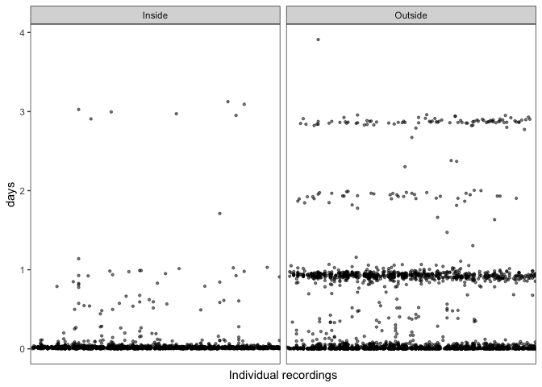

Time in number of days that each drone remains inside and outside the hive during the mating season.

End of the document - Back to Top